*Note: These are notes live-tex’d from a graduate course in Algebra taught by Dan Nakano at the University of Georgia in Fall 2019. As such, any errors or inaccuracies are almost certainly my own.*

# Algebra

University of Georgia, Fall 2019

D. Zack Garza

University of Georgia  
dzackgarza@gmail.com

Last updated: 2020-10-22

# Summary

- Groups and rings, including Sylow theorems,
- Classifying small groups,
- Finitely generated abelian groups,
- Jordan-Holder theorem,
- Solvable groups,
- Simplicity of the alternating group,
- Euclidean domains,
- Principal ideal domains,
- Unique factorization domains,
- Noetherian rings,
- Hilbert basis theorem,
- Zorn’s lemma, and
- Existence of maximal ideals and vector space bases.

Previous course web pages:

- [Fall 2017, Asilata Bapat](https://asilata.github.io/8000fall17/)

# Thursday August 15th

> We’ll be using Hungerford’s Algebra text.

## Definitions

The following definitions will be useful to know by heart:

- The order of a group
- Cartesian product
- Relations
- Equivalence relation
- Partition
- Binary operation
- Group
- Isomorphism
- Abelian group
- Cyclic group
- Subgroup
- Greatest common divisor
- Least common multiple
- Permutation
- Transposition
- Orbit
- Cycle
- The symmetric group $S_{n}$
- The alternating group $A_{n}$
- Even and odd permutations
- Cosets
- Index
- The direct product of groups
- Homomorphism
- Image of a function
- Inverse image of a function
- Kernel
- Normal subgroup
- Factor group
- Simple group

Here is a rough outline of the course:

- Group Theory
  - Groups acting on sets
  - Sylow theorems and applications
  - Classification
  - Free and free abelian groups
  - Solvable and simple groups
  - Normal series
- Galois Theory
  - Field extensions
  - Splitting fields
  - Separability
  - Finite fields
  - Cyclotomic extensions
  - Galois groups
  - Solvability by radicals
- Module theory
  - Free modules
  - Homomorphisms
  - Projective and injective modules
  - Finitely generated modules over a PID
- Linear Algebra
  - Matrices and linear transformations
  - Rank and determinants
  - Canonical forms
  - Characteristic polynomials
  - Eigenvalues and eigenvectors

## Preliminaries

**Definition**: A **group** is an ordered pair $(G, {\,\cdot\,}: G\times G \to G)$ where $G$ is a set and ${\,\cdot\,}$ is a binary operation, which satisfies the following axioms:

1. **Associativity**: $(g_1 g_2)g_3 = g_1(g_2 g_3)$,
2. **Identity**: $\exists e\in G {~\mathrel{\Big|}~}ge = eg = g$,
3. **Inverses**: $g\in G \implies \exists h\in G {~\mathrel{\Big|}~}gh = gh = e$.

*Examples of groups:*

- $({\mathbb{Z}}, +)$
- $({\mathbb{Q}}, +)$
- $({\mathbb{Q}}^{\times}, \times)$
- $({\mathbb{R}}^{\times}, \times)$
- ($\operatorname{GL}(n, {\mathbb{R}}), \times) = \left\{{A \in \mathrm{Mat}_n {~\mathrel{\Big|}~}\det(A) \neq 0}\right\}$
- $(S_n, \circ)$

**Definition:** A subset $S \subseteq G$ is a **subgroup** of $G$ iff

1. **Closure**: $s_1, s_2 \in S \implies s_1 s_2 \in S$
2. **Identity**: $e\in S$
3. **Inverses**: $s\in S \implies s^{-1}\in S$

We denote such a subgroup $S \leq G$.

*Examples of subgroups:*

- $({\mathbb{Z}}, +) \leq ({\mathbb{Q}}, +)$
- ${\text{SL}}(n, {\mathbb{R}}) \leq \operatorname{GL}(n, {\mathbb{R}})$, where ${\text{SL}}(n, {\mathbb{R}}) = \left\{{A\in \operatorname{GL}(n, {\mathbb{R}}) {~\mathrel{\Big|}~}\det(A) = 1}\right\}$

## Cyclic Groups

**Definition**: A group $G$ is **cyclic** iff $G$ is generated by a single element.

*Exercise*: Show
$$\begin{align*} \left\langle{g}\right\rangle = \left\{{g^n {~\mathrel{\Big|}~}n\in{\mathbb{Z}}}\right\} \cong \cap_{g\in G} \left\{{H \mathrel{\Big|}H \leq G \text{ and } g\in H}\right\} .\end{align*}$$

**Theorem:** Let $G$ be a cyclic group, so $G = \left\langle{g}\right\rangle$.

- If ${\left\lvert {G} \right\rvert} = \infty$, then $G \cong {\mathbb{Z}}$.
- If ${\left\lvert {G} \right\rvert} = n < \infty$, then $G \cong {\mathbb{Z}}_n$.

**Definition**: Let $H \leq G$, and define a **right coset of $G$** by $aH = \left\{{ah {~\mathrel{\Big|}~}H \in H}\right\}$.

A similar definition can be made for **left cosets**.

**The “Fundamental Theorem of Cosets”**:
$$\begin{align*} aH = bH \iff b^{-1}a \in H \text{ and } Ha = Hb \iff ab^{-1}\in H .\end{align*}$$

**Some facts:**

- Cosets partition $H$, i.e.
  $$\begin{align*} b\not\in H \implies aH \cap bH = \left\{{e}\right\} .\end{align*}$$
- ${\left\lvert {H} \right\rvert} = {\left\lvert {aH} \right\rvert} = {\left\lvert {Ha} \right\rvert}$ for all $a\in G$.

**Theorem (Lagrange)**: If $G$ is a finite group and $H \leq G$, then ${\left\lvert {H} \right\rvert} {~\Bigm|~}{\left\lvert {G} \right\rvert}$.

**Definition** A subgroup $N \leq G$ is **normal** iff $gN = Ng$ for all $g\in G$, or equivalently $gNg^{-1}\subseteq N$. (I denote this $N {~\trianglelefteq~}G$.)

When $N {~\trianglelefteq~}G$, the set of left/right cosets of $N$ themselves have a group structure. So we define
$$\begin{align*} G/N = \left\{{gN {~\mathrel{\Big|}~}g\in G}\right\} \text{ where } (g_1 N)\cdot (g_2 N) \mathrel{\vcenter{:}}=(g_1 g_2) N .\end{align*}$$

Given $H, K \leq G$, define
$$\begin{align*} HK = \left\{{hk \mathrel{\Big|}h\in H, ~k\in K}\right\} .\end{align*}$$

We have a general formula,
$$\begin{align*} {\left\lvert {HK} \right\rvert} = \frac{{\left\lvert {H} \right\rvert} {\left\lvert {K} \right\rvert}}{{\left\lvert {H \cap K} \right\rvert}}. \end{align*}$$

## Homomorphisms

**Definition**: Let $G,G'$ be groups, then $\varphi: G \to G'$ is a **homomorphism** if $\varphi(ab) = \varphi(a) \varphi(b)$.

*Examples of homomorphisms*:

- $\exp\qty{:} ({\mathbb{R}}, +) \to ({\mathbb{R}}^{> 0}, {\,\cdot\,})$ since
  $$\begin{align*} \exp\qty{(}a+b) \mathrel{\vcenter{:}}= e^{a+b} = e^a e^b \mathrel{\vcenter{:}}=\exp\qty{(}a) \exp\qty{(}b) .\end{align*}$$
- $\det: (\operatorname{GL}(n, {\mathbb{R}}), \times) \to ({\mathbb{R}}^{\times}, \times)$ since
  $$\begin{align*}\det(AB) = \det(A) \det(B).\end{align*}$$
- Let $N {~\trianglelefteq~}G$ and define

$$\begin{align*} \varphi: G &\to G/N \\ g &\mapsto gN .\end{align*}$$

- Let $\varphi: {\mathbb{Z}}\to {\mathbb{Z}}_n$ where $\phi(g) = [g] = g \mod n$ where ${\mathbb{Z}}_n \cong {\mathbb{Z}}/n{\mathbb{Z}}$

**Definition**: Let $\varphi: G \to G'$. Then $\varphi$ is a **monomorphism** iff it is injective, an **epimorphism** iff it is surjective, and an **isomorphism** iff it is bijective.

## Direct Products

Let $G_1, G_2$ be groups, then define
$$\begin{align*} G_1 \times G_2 = \left\{{(g_1, g_2) {~\mathrel{\Big|}~}g_1 \in G, g_2 \in G_2}\right\} \text{ where } (g_1, g_2)(h_1, h_2) = (g_1 h_1, g_2 ,h_2). \end{align*}$$

We have the formula ${\left\lvert {G_1 \times G_2} \right\rvert} = {\left\lvert {G_1} \right\rvert} {\left\lvert {G_2} \right\rvert}$.

## Finitely Generated Abelian Groups

**Definition**: We say a group is **abelian** if $G$ is commutative, i.e. $g_1, g_2 \in G \implies g_1 g_2 = g_2 g_1$.

**Definition**: A group is **finitely generated** if there exist $\left\{{g_1, g_2, \cdots g_n}\right\} \subseteq G$ such that $G = \left\langle{g_1, g_2, \cdots g_n}\right\rangle$.

This generalizes the notion of a cyclic group, where we can simply intersect all of the subgroups that contain the $g_i$ to define it.

We know what cyclic groups look like – they are all isomorphic to ${\mathbb{Z}}$ or ${\mathbb{Z}}_n$. So now we’d like a structure theorem for abelian finitely generated groups.

**Theorem**: Let $G$ be a finitely generated abelian group.

Then
$$\begin{align*}G \cong {\mathbb{Z}}^r \times \displaystyle\prod_{i=1}^s {\mathbb{Z}}_{p_i^{\alpha _i}}\end{align*}$$
for some finite $r,s \in {\mathbb{N}}$ where the $p_i$ are (not necessarily distinct) primes.

*Example*: Let $G$ be a finite abelian group of order 4.

Then $G \cong {\mathbb{Z}}_4$ or ${\mathbb{Z}}_2^2$, which are not isomorphic because every element in ${\mathbb{Z}}_2^2$ has order 2 where ${\mathbb{Z}}_4$ contains an element of order 4.

## Fundamental Homomorphism Theorem

Let $\varphi: G \to G'$ be a group homomorphism and define
$$\begin{align*} \ker \varphi \mathrel{\vcenter{:}}=\left\{{g\in G {~\mathrel{\Big|}~}\varphi(g) = e'}\right\} .\end{align*}$$

### The First Homomorphism Theorem

This map is given by
$$\begin{align*} \varphi'(g(\ker \varphi)) = \varphi(g) .\end{align*}$$

*Exercise*: Check that $\varphi$ is well-defined.

### The Second Theorem

**Theorem**: Let $K, N \leq G$ where $N {~\trianglelefteq~}G$. Then
$$\begin{align*} \frac K {N \cap K} \cong \frac {NK} N \end{align*}$$

*Proof:* Define a map

$$\begin{align*} K &\xrightarrow{\varphi} NK/N \\ k &\mapsto kN .\end{align*}$$

You can show that $\varphi$ is onto, then look at $\ker \varphi$; note that
$$\begin{align*} kN = \varphi(k) = N \iff k \in N ,\end{align*}$$

and so $\ker \varphi = N \cap K$.

$\hfill\blacksquare$

# Tuesday August 20th

## The Fundamental Homomorphism Theorems

**Theorem 1:** Let $\varphi: G \to G'$ be a homomorphism. Then there is a canonical homomorphism $\eta: G \to G/\ker \varphi$ such that the usual diagram commutes.

Moreover, this map induces an isomorphism $G /\ker \varphi \cong \operatorname{im}({\varphi})$.

**Theorem 2:** Let $K, N \leq G$ and suppose $N {~\trianglelefteq~}G$. Then there is an isomorphism
$$\begin{align*} \frac K {K \cap N} \cong \frac {NK} {N} \end{align*}$$

*Proof Sketch:* Show that $K \cap N {~\trianglelefteq~}G$, and $NK$ is a subgroup exactly because $N$ is normal.

**Theorem 3:** Let $H, K {~\trianglelefteq~}G$ such that $H \leq K$.

Then

1. $H/K$ is normal in $G/K$.
2. The quotient $(G/K) / (H/K) \cong G/H$.

*Proof:* We’ll use the first theorem.

Define a map
$$\begin{align*} \phi: G/K &\to G/H \\ gk &\mapsto gH .\end{align*}$$

*Exercise*: Show that $\phi$ is surjective, and that $\ker \phi \cong H/K$.

$\hfill\blacksquare$

## Permutation Groups

Let $A$ be a set, then a *permutation* on $A$ is a bijective map $A {\circlearrowleft}$. This can be made into a group with a binary operation given by composition of functions. Denote $S_{A}$ the set of permutations on $A$.

**Theorem:** $S_{A}$ is in fact a group.

*Proof:* Exercise. Follows from checking associativity, inverses, identity, etc.

$\hfill\blacksquare$

In the special case that $A = \left\{{1, 2, \cdots n}\right\}$, then $S_{n} \mathrel{\vcenter{:}}= S_{A}$.

Recall two line notation
$$\begin{align*} \left(\begin{matrix} 1 & 2 & \cdots & n\\ \sigma(1) & \sigma(2) & \cdots & \sigma(n) \end{matrix}\right) \end{align*}$$

Moreover, ${\left\lvert {S_{n}} \right\rvert} = n!$ by a combinatorial counting argument.

*Example:* $S_{3}$ is the symmetries of a triangle.

*Example:* The symmetries of a square are *not* given by $S_{4}$, it is instead $D_{4}$.

## Orbits and the Symmetric Group

Permutations $S_{A}$ *act* on $A$, and if $\sigma \in S_{A}$, then $\left\langle{\sigma}\right\rangle$ also acts on $A$.

Define $a \sim b$ iff there is some $n$ such that $\sigma^{n}(a) = b$. This is an equivalence relation, and thus induces a partition of $A$. See notes for diagram. The equivalence classes under this relation are called the *orbits* under $\sigma$.

*Example:*
$$\begin{align*} \left(\begin{matrix} 1 & 2 & 3 & 4 & 5 & 6 & 7 & 8 \\ 8 & 2 & 6 & 3 & 7 & 4 & 5 & 1 \end{matrix}\right) = (1 8)(2)(3 6 4)(5 7). \end{align*}$$

**Definition:** A permutation $\sigma \in S_{n}$ is a *cycle* iff it contains at most one orbit with more than one element.

The *length* of a cycle is the number of elements in the largest orbit.

Recall cycle notation: $\sigma = (\sigma(1) \sigma(2) \cdots \sigma(n))$.

> Note that this is read right-to-left by convention!

**Theorem:** Every permutation $\sigma \in S_{n}$ can be written as a product of disjoint cycles.

**Definition:** A *transposition* is a cycle of length 2.

**Proposition:** Every permutation is a product of transpositions.

*Proof:*
$$\begin{align*} (a_{1} a_{2} \cdots a_{n}) = (a_{1} a_{n}) (a_{1} a_{n-1}) \cdots (a_{1} a_{2}) .\end{align*}$$

$\hfill\blacksquare$

This is not a unique decomposition, however, as e.g. $\text{id}= (1 2)^{2} = (3 4)^{2}$.

**Theorem:** Any $\sigma \in S_{n}$ can be written as **either**

- An even number of transpositions, or
- An odd number of transpositions.

*Proof:*

Define
$$\begin{align*} A_{n} = \left\{{\sigma \in S_{n} {~\mathrel{\Big|}~}\sigma\text{ is even}}\right\} .\end{align*}$$

We claim that $A_{n} {~\trianglelefteq~}S_{n}$.

1. Closure: If $\tau_{1}, \tau_{2}$ are both even, then $\tau_{1}\tau_{2}$ also has an even number of transpositions.
2. The identity has an even number of transpositions, since zero is even.
3. Inverses: If $\sigma = \prod_{i=1}^{s} \tau_{i}$ where $s$ is even, then $\sigma^{-1}= \prod_{i=1}^{s} \tau_{s-i}$. But each $\tau$ is order 2, so $\tau^{-1}= \tau$, so there are still an even number of transpositions.

So $A_{n}$ is a subgroup.

It is normal because it is index 2, or the kernel of a homomorphism, or by a direct computation.

## Groups Acting on Sets

Think of this as a generalization of a $G{\hbox{-}}$module.

**Definition:** A group $G$ is said to *act* on a set $X$ if there exists a map $G\times X \to X$ such that

1. $e\curvearrowright x = x$
2. $(g_{1} g_{2})\curvearrowright x = g_{1} \curvearrowright(g_{2} \curvearrowright x)$.

*Examples:*

1. $G = S_{A} \curvearrowright A$
2. $H \leq G$, then $G \curvearrowright X = G/H$ where $g \curvearrowright xH = (gx)H$.
3. $G \curvearrowright G$ by conjugation, i.e. $g\curvearrowright x = gxg^{-1}$.

**Definition:** Let $x\in X$, then define the **stabilizer subgroup**
$$\begin{align*} G_{x} = \left\{{g\in G {~\mathrel{\Big|}~}g\curvearrowright x = x}\right\} \leq G \end{align*}$$

We can also look at the dual notion,
$$\begin{align*} X_{g} = \left\{{x\in X {~\mathrel{\Big|}~}g\curvearrowright x = x}\right\}. \end{align*}$$

We then define the *orbit* of an element $x$ as
$$\begin{align*} Gx = \left\{{g\curvearrowright x {~\mathrel{\Big|}~}g\in G}\right\} \end{align*}$$
and we have a similar result where $x\sim y \iff x\in Gy$, and the orbits partition $X$.

**Theorem:** Let $G$ act on $X$. We want to know the number of elements in an orbit, and it turns out that

$$\begin{align*} {\left\lvert {Gx} \right\rvert} = [G: G_{x}] \end{align*}$$

*Proof:* Construct a map $Gx \xrightarrow{\psi} G/Gx$ where $\psi(g\curvearrowright x) = g Gx$.

*Exercise:* Show that this is well-defined, so if 2 elements are equal then they go to the same coset.

*Exercise*: Show that this is surjective.

Injectivity: $\psi(g_{1} x) = \psi(g_{2} x)$, so $g_{1} Gx = g_{2} Gx$ and $(g_{2}^{-1}g_{1}) Gx = Gx$ so
$$\begin{align*} g_{2}^{-1}g_{1} \in Gx \iff g_{2}^{-1}g_{1} \curvearrowright x = x \iff g_{1}x = g_{2} x .\end{align*}$$
$\hfill\blacksquare$

Next time: Burnside’s theorem, proving the Sylow theorems.

# Thursday August 22nd

## Group Actions

Let $G$ be a group and $X$ be a set; we say $G$ *acts* on $X$ (or that $X$ is a $G{\hbox{-}}$ set) when there is a map $G\times X \to X$ such that $ex = x$ and
$$\begin{align*} (gh) \curvearrowright x = g \curvearrowright(h \curvearrowright x) .\end{align*}$$

We then define the **stabilizer** of $x$ as
$$\begin{align*} \mathrm{Stab}_G(x) = G_x \mathrel{\vcenter{:}}=\left\{{g\in G {~\mathrel{\Big|}~}g\curvearrowright x = x}\right\} \leq G, \end{align*}$$

and the **orbit**
$$\begin{align*} G.x = \mathcal O_x \mathrel{\vcenter{:}}=\left\{{g\curvearrowright x {~\mathrel{\Big|}~}x\in X}\right\} \subseteq X. \end{align*}$$

When $G$ is finite, we have
$$\begin{align*} {\left\lvert {G.x} \right\rvert} = \frac{{\left\lvert {G} \right\rvert}}{{\left\lvert {G_x} \right\rvert}}. \end{align*}$$

We can also consider the **fixed points** of $X$,
$$\begin{align*} X_g = \left\{{x\in X \mathrel{\Big|}g\curvearrowright x = x ~~\forall g\in G}\right\} \subseteq X \end{align*}$$

## Burnside’s Theorem

**Theorem (Burnside):** Let $X$ be a $G{\hbox{-}}$set and $v \mathrel{\vcenter{:}}={\left\lvert {X/G} \right\rvert}$ be the number of orbits. Then
$$\begin{align*} v {\left\lvert {G} \right\rvert} = \sum_{g\in G} {\left\lvert {X_g} \right\rvert}. \end{align*}$$

*Proof:* Define
$$\begin{align*} N = \left\{{(g,x) \mathrel{\Big|}g\curvearrowright x = x}\right\} \subseteq G \times X ,\end{align*}$$

we then have

$$\begin{align*} {\left\lvert {N} \right\rvert} &= \sum_{g\in G} {\left\lvert {X_g} \right\rvert} \\ &= \sum_{x\in X} {\left\lvert {G_x} \right\rvert} \\ &= \sum_{x\in X} \frac{{\left\lvert {G} \right\rvert}}{{\left\lvert {G.x} \right\rvert}} \quad\text{by Orbit-Stabilizer} \\ &= {\left\lvert {G} \right\rvert} \left( \sum_{x\in X} \frac{1}{{\left\lvert {G.x} \right\rvert}} \right) \\ &= {\left\lvert {G} \right\rvert} \sum_{G.x ~\in~ X/G} \left( \sum_{y ~\in~ G.x} \frac{1}{{\left\lvert {G.x} \right\rvert}} \right) \\ &= {\left\lvert {G} \right\rvert} \sum_{G.x ~\in~ X/G} \left( {\left\lvert {G.x} \right\rvert} \frac{1}{{\left\lvert {G.x} \right\rvert}} \right) \\ &= {\left\lvert {G} \right\rvert} \sum_{G.x ~\in~ X/G} 1 \\ &= {\left\lvert {G} \right\rvert} v .\end{align*}$$

The last two equalities follow from the following fact: since the orbits partition $X$, say into $X = \displaystyle{\coprod}_{i=1}^v \sigma_i$, so let $\sigma = \left\{{\sigma_i \mathrel{\Big|}1 \leq i \leq v}\right\}$.

By abuse of notation, replace each orbit in $\sigma$ with a representative element $x_i\in \sigma_i \subset X$.

We then have
$$\begin{align*} \sum_{x \in \sigma} \frac{1}{{\left\lvert {G.x} \right\rvert}} = \frac{1}{{\left\lvert {G.x} \right\rvert}} {\left\lvert {\sigma} \right\rvert} = 1. \end{align*}$$

$\hfill\blacksquare$

*Application:* Consider seating 10 people around a circular table. How many distinct seating arrangements are there?

By Burnside, we have
$$\begin{align*} v = \frac{1}{{\left\lvert {G} \right\rvert}} \sum_{g\in G} {\left\lvert {X_g} \right\rvert} = \frac{1}{10} (10!) = 9! \end{align*}$$

since $X_g = \left\{{x\in X \mathrel{\Big|}g\curvearrowright x = x}\right\} = \emptyset$ unless $g = e$, and $X_e = X$.

## Sylow Theory

Recall Lagrange’s theorem:

If $H \leq G$ and $G$ is finite, then ${\left\lvert {H} \right\rvert}$ divides ${\left\lvert {G} \right\rvert}$.

Consider the converse: if $n$ divides ${\left\lvert {G} \right\rvert}$, does there exist a subgroup of size $n$?

The answer is **no** in general, and a counterexample is $A_4$ which has $4!/2 = 12$ elements but no subgroup of order 6.

### Class Functions

Let $X$ be a $G{\hbox{-}}$set, and choose orbit representatives $x_1 \cdots x_v$.

Then
$$\begin{align*} {\left\lvert {X} \right\rvert} = \sum_{i=1}^v {\left\lvert {G .x_i} \right\rvert}. \end{align*}$$

We can then separately count all orbits with exactly one element, which is exactly
$$\begin{align*} X_G = \left\{{x\in G \mathrel{\Big|}g\curvearrowright x = x ~ \forall g\in G}\right\} \end{align*}$$
.

We then have
$$\begin{align*} {\left\lvert {X} \right\rvert} = {\left\lvert {X_G} \right\rvert} + \sum_{i=j}^v {\left\lvert {G. x_i} \right\rvert} \end{align*}$$
for some $j$ where ${\left\lvert {G.x_i} \right\rvert} > 1$ for all $i \geq j$.

**Theorem:** Let $G$ be a group of order $p^n$ for $p$ a prime.

Then
$$\begin{align*} {\left\lvert {X} \right\rvert} = {\left\lvert {X_G} \right\rvert} \mod p .\end{align*}$$

*Proof:* We know that
$$\begin{align*} {\left\lvert {G.x_i} \right\rvert} = [G : G_{x_i}] \text{ for } j \leq i \leq v \text{ and } {\left\lvert {Gx_i} \right\rvert} > 1 \implies G.x_i \neq G ,\end{align*}$$
and thus $p$ divides $[G: G x_i]$. The result follows.

$\hfill\blacksquare$

*Application:* If ${\left\lvert {G} \right\rvert} = p^n$, then the center $Z(G)$ is nontrivial.

Let $X=G$ act on itself by conjugation, so $g\curvearrowright x = gxg^{-1}$. Then
$$\begin{align*} X_G = \left\{{x\in G {~\mathrel{\Big|}~}gxg^{-1}= x}\right\} = \left\{{x\in G {~\mathrel{\Big|}~}gx = xg}\right\} = Z(G) \end{align*}$$

But then, by the previous theorem, we have
$$\begin{align*} {\left\lvert {Z(G)} \right\rvert} \equiv {\left\lvert {X} \right\rvert}\equiv {\left\lvert {G} \right\rvert} \mod p ,\end{align*}$$
but since $Z(G) \leq G$ we have ${\left\lvert {Z(G)} \right\rvert} \cong 0 \mod p$. So in particular, $Z(G) \neq \left\{{e}\right\}$.

**Definition:** A group $G$ is a **$p{\hbox{-}}$group** iff every element in $G$ has order $p^k$ for some $k$. A subgroup is a $p{\hbox{-}}$group exactly when it is a $p{\hbox{-}}$group in its own right.

### Cauchy’s Theorem

**Theorem (Cauchy):** Let $G$ be a finite group, where $p$ is prime and divides ${\left\lvert {G} \right\rvert}$. Then $G$ has an element (and thus a subgroup) of order $p$.

*Proof:* Consider
$$\begin{align*} X = \left\{{(g_1, g_2, \cdots , g_p) \in G^{\oplus p} \mathrel{\Big|}g_1g_2\cdots g_p = e}\right\} .\end{align*}$$

Given any $p-1$ elements, say $g_1 \cdots g_{p-1}$, the remaining element is completely determined by $g_p = (g_1 \cdots g_{p-1})^{-1}$.

So ${\left\lvert {X} \right\rvert} = {\left\lvert {G} \right\rvert}^{p-1}$.and since $p {~\Bigm|~}{\left\lvert {G} \right\rvert}$, we have $p {~\Bigm|~}{\left\lvert {X} \right\rvert}$.

Now let $\sigma \in S_p$ the symmetric group act on $X$ by index permutation, i.e.
$$\begin{align*} \sigma \curvearrowright(g_1, g_2 \cdots g_p) = (g_{\sigma(1)}, g_{\sigma(2)}, \cdots, g_{\sigma(p)}) .\end{align*}$$

*Exercise*: Check that this gives a well-defined group action.

Let $\sigma = (1~2~\cdots~p) \in S_p$, and note $\left\langle{\sigma}\right\rangle \leq S_p$ also acts on $X$ where ${\left\lvert {\left\langle{\sigma}\right\rangle} \right\rvert} = p$. Therefore we have
$$\begin{align*} {\left\lvert {X} \right\rvert} = {\left\lvert {X_{\left\langle{\sigma}\right\rangle}} \right\rvert} \mod p. \end{align*}$$

Since $p{~\Bigm|~}{\left\lvert {X} \right\rvert}$, it follows that ${\left\lvert {X_{\left\langle{\sigma}\right\rangle}} \right\rvert} = 0 \mod p$, and thus $p {~\Bigm|~}{\left\lvert {X_{\left\langle{\sigma}\right\rangle}} \right\rvert}$.

If $\left\langle{\sigma}\right\rangle$ fixes $(g_1, g_2, \cdots g_p)$, then $g_1 = g_2 = \cdots g_p$.

Note that $(e, e, \cdots) \in X_{\left\langle{\sigma}\right\rangle}$, as is $(a, a, \cdots a)$ since $p {~\Bigm|~}{\left\lvert {X_{\left\langle{\sigma}\right\rangle}} \right\rvert}$. So there is some $a\in G$ such that $a^p = 1$. Moreover, $\left\langle{a}\right\rangle \leq G$ is a subgroup of size $p$.

$\hfill\blacksquare$

### Normalizers

Let $G$ be a group and $X = S$ be the set of subgroups of $G$. Let $G$ act on $X$ by $g\curvearrowright H = gHg^{-1}$. What is the stabilizer?

$$\begin{align*} G_x = G_H = \left\{{g\in G \mathrel{\Big|}gHg^{-1}= H}\right\} ,\end{align*}$$
making $G_H$ the largest subgroup such that $H {~\trianglelefteq~}G_H$.

So we **define** $N_G(H) \mathrel{\vcenter{:}}= G_H$.

*Lemma:* Let $H$ be a $p{\hbox{-}}$subgroup of $G$ of order $p^n$. Then
$$\begin{align*} [N_G(H) : H] = [G : H] \mod p .\end{align*}$$

*Proof:* Let $S = G/H$ be the set of left $H{\hbox{-}}$cosets in $G$. Now let $H$ act on $S$ by
$$\begin{align*} H\curvearrowright x + H \mathrel{\vcenter{:}}=(hx) + H .\end{align*}$$

By a previous theorem, ${\left\lvert {G/H} \right\rvert} = {\left\lvert {S} \right\rvert} = {\left\lvert {S_H} \right\rvert} \mod p$, where ${\left\lvert {G/H} \right\rvert} = [G: H]$. What is $S_H$?

This is given by
$$\begin{align*} S_H = \left\{{x + H \in S {~\mathrel{\Big|}~}xHx^{-1}\in H \forall h\in H}\right\} .\end{align*}$$

Therefore $x\in N_G(H)$.

$\hfill\blacksquare$

**Corollary:** Let $H \leq G$ be a subgroup of order $p^n$. If $p {~\Bigm|~}[G: H]$ then $N_G(H) \neq H$.

*Proof:* Exercise. $\hfill\blacksquare$

**Theorem:** Let $G$ be a finite group, then $G$ is a $p{\hbox{-}}$group $\iff {\left\lvert {G} \right\rvert} = p^n$ for some $n\geq 1$.

*Proof:* Suppose ${\left\lvert {G} \right\rvert} = p^n$ and $a \in G$. Then ${\left\lvert {\left\langle{a}\right\rangle} \right\rvert} = p^\alpha$ for some $\alpha$.

Conversely, suppose $G$ is a $p{\hbox{-}}$group. Factor ${\left\lvert {G} \right\rvert}$ into primes and suppose $\exists q$ such that $q {~\Bigm|~}{\left\lvert {G} \right\rvert}$ but $q \neq p$.

By Cauchy, we can then get a subgroup $\left\langle{c}\right\rangle$ such that ${\left\lvert {\left\langle{c}\right\rangle} \right\rvert} {~\Bigm|~}q$, but then ${\left\lvert {G} \right\rvert} \neq p^n$.

$\hfill\blacksquare$

# Tuesday August 27th

Let $G$ be a finite group and $p$ a prime. TFAE:

- ${\left\lvert {H} \right\rvert} = p^n$ for some $n$
- Every element of $H$ has order $p^\alpha$ for some $\alpha$.

If either of these are true, we say $H$ is a *$p{\hbox{-}}$group*.

Let $H$ be a $p{\hbox{-}}$group, last time we proved that if $p {~\Bigm|~}[G : H]$ then $N_G(H) \neq H$.

## Sylow Theorems

Let $G$ be a finite group and suppose ${\left\lvert {G} \right\rvert} = p^n m$ where $(m, n) = 1$. Then

### Sylow 1

> Idea: take a prime factorization of ${\left\lvert {G} \right\rvert}$, then there are subgroups of order $p^i$ for *every* prime power appearing, up to the maximal power.
1. $G$ contains a subgroup of order $p^i$ for every $1 \leq i \leq n$.
2. Every subgroup $H$ of order $p^i$ where $i < n$ is a normal subgroup in a subgroup of order $p^{i+1}$.

*Proof:* By induction on $i$. For $i=1$, we know this by Cauchy’s theorem. If we show (2), that shows (1) as a consequence.

So suppose this holds for $i < n$. Let $H \leq G$ where ${\left\lvert {H} \right\rvert} = p^i$, we now want a subgroup of order $p^{i+1}$. Since $p{~\Bigm|~}[G: H]$, by the previous theorem, $H < N_G(H)$ is a proper subgroup (?).

Now consider the canonical projection $N_G(H) \to N_G(H) /H$. Since
$$\begin{align*} p {~\Bigm|~}[N_G(H) : H] = {\left\lvert {N_G(H)/ H} \right\rvert} ,\end{align*}$$
by Cauchy there is a subgroup of order $p$ in this quotient. Call it $K$. Then $\pi^{-1}(K) \leq N_G(H)$.

*Exercise*: Show that ${\left\lvert {\phi^{-1}(K)} \right\rvert} = p^{i+1}$.

It now follows that $H {~\trianglelefteq~}\phi^{-1}(K)$. $\hfill\blacksquare$

**Definition**: For $G$ a finite group and ${\left\lvert {G} \right\rvert} = p^n m$ where $p$ does not divide $m$.

Then a subgroup of order $p^n$ is called a **Sylow $p{\hbox{-}}$subgroup**.

> Note: by Sylow 1, these exist.

### Sylow 2

If $P_1, P_2$ are Sylow $p{\hbox{-}}$subgroups of $G$, then $P_1$ and $P_2$ are conjugate.

*Proof:* Let $\mathcal L$ be the left cosets of $P_1$, i.e. $\mathcal L = G/P_1$.

Let $P_2$ act on $\mathcal L$ by
$$\begin{align*} p_2 \curvearrowright(g + P_1) \mathrel{\vcenter{:}}=(p_2g) + P_1 .\end{align*}$$

By a previous theorem about orbits and fixed points, we have
$$\begin{align*} {\left\lvert {\mathcal L_{P_2}} \right\rvert} = {\left\lvert {\mathcal L} \right\rvert} \mod p. \end{align*}$$

Since $p$ does not divide ${\left\lvert {\mathcal L} \right\rvert}$, we have $p$ does not divide ${\left\lvert {\mathcal L_{P_2}} \right\rvert}$. So $\mathcal L_{P_2}$ is nonempty.

So there exists a coset $xP_1$ such that $xP_1 \in \mathcal L_{P_2}$, and thus
$$\begin{align*} yxP_1 = xP_1 \text{ for all } y\in P_2 .\end{align*}$$

Then $x^{-1}y x P_1 = P_1$ for all $y\in P_2$, and so $x^{-1}P_2 x = P_1$. So $P_1$ and $P_2$ are conjugate.

$\hfill\blacksquare$

### Sylow 3

Let $G$ be a finite group, and $p{~\Bigm|~}{\left\lvert {G} \right\rvert}$. Let $r_p$ be the number of Sylow $p{\hbox{-}}$subgroups of $G$.

Then

- $r_p \cong 1 \mod p$.
- $r_p {~\Bigm|~}{\left\lvert {G} \right\rvert}$.
- $r_p = [G : N_G(P)]$

*Proof:*

Let $X = \mathcal S$ be the set of Sylow $p{\hbox{-}}$subgroups, and let $P \in X$ be a fixed Sylow $p{\hbox{-}}$subgroup.

Let $P \curvearrowright\mathcal S$ by conjugation, so for $\overline P \in \mathcal S$ let $x \curvearrowright\overline P = x \overline P x^{-1}$.

By a previous theorem, we have
$$\begin{align*} {\left\lvert {\mathcal S} \right\rvert} = \mathcal{S}_P \mod p \end{align*}$$

What are the fixed points $\mathcal{S}_P$?
$$\begin{align*} \mathcal{S}_P = \left\{{T \in \mathcal S {~\mathrel{\Big|}~}xTx^{-1}= T \quad \forall x\in P}\right\}. \end{align*}$$

Let $\mathcal T \in \mathcal{S}_P$, so $xTx^{-1}= T$ for all $x\in P$.

Then $P \leq N_G(T)$, so both $P$ and $T$ are Sylow $p{\hbox{-}}$ subgroups in $N_G(H)$ as well as $G$.

So there exists a $f\in N_G(T)$ such that $T = gPg^{-1}$. But the point is that in the normalizer, there is only **one** Sylow $p{\hbox{-}}$ subgroup.

But then $T$ is the unique largest normal subgroup of $N_G(T)$, which forces $T = P$.

Then $\mathcal{S}_P = \left\{{P}\right\}$, and using the formula, we have $r_p \cong 1 \mod p$.

Now modify this slightly by letting $G$ act on $\mathcal S$ (instead of just $P$) by conjugation.

Since all Sylows are conjugate, by Sylow (1) there is only one orbit, so $\mathcal S = GP$ for $P \in \mathcal S$. But then
$$\begin{align*} r_p = {\left\lvert {\mathcal S} \right\rvert} = {\left\lvert {GP} \right\rvert} = [G: G_p] {~\Bigm|~}{\left\lvert {G} \right\rvert}. \end{align*}$$

Note that this gives a precise formula for $r_p$, although the theorem is just an upper bound of sorts, and $G_p = N_G(P)$.

## Applications of Sylow Theorems

Of interest historically: classifying finite *simple* groups, where a group $G$ is *simple* If $N {~\trianglelefteq~}G$ and $N \neq \left\{{e}\right\}$, then $N=G$.

*Example:* Let $G = {\mathbb{Z}}_p$, any subgroup would need to have order dividing $p$, so $G$ must be simple.

*Example:* $G = A_n$ for $n\geq 5$ (see Galois theory)

One major application is proving that groups of a certain order are *not* simple.

*Applications:*

**Proposition:** Let ${\left\lvert {G} \right\rvert} = p^n q$ with $p > q$. Then $G$ is not simple.

*Proof:*

> Strategy: Find a proper normal nontrivial subgroup using Sylow theory. Can either show $r_p = 1$, or produce normal subgroups by intersecting distinct Sylow p-subgroups.

Consider $r_p$, then $r_p = p^\alpha q^\beta$ for some $\alpha, \beta$. But since $r_p \cong 1 \mod p$, $p$ does not divide $r_p$, we must have $r_p = 1, q$.

But since $q < p$ and $q\neq 1 \mod p$, this forces $r_p = 1$.

So let $P$ be a sylow $p{\hbox{-}}$subgroup, then $P < G$. Then $gPg^{-1}$ is also a sylow, but there’s only 1 of them, so $P$ is normal.

$\hfill\blacksquare$

**Proposition**: Let ${\left\lvert {G} \right\rvert} = 45$, then $G$ is not simple.

*Proof*: Exercise.

$\hfill\blacksquare$

**Proposition**: Let ${\left\lvert {G} \right\rvert} = p^n$, then $G$ is not simple if $n > 1$.

*Proof:* By Sylow (1), there is a normal subgroup of order $p^{n-1}$ in $G$.

$\hfill\blacksquare$

**Proposition:** Let ${\left\lvert {G} \right\rvert} = 48$, then $G$ is not simple.

*Proof:*

Note $48 = 2^4 3$, so consider $r_2$, the number of Sylow 2-subgroups. Then $r_2 \cong 1 \mod 2$ and $r_2 {~\Bigm|~}48$. So $r_2 = 1, 3$. If $r_2 = 1$, we’re done, otherwise suppose $r_2 = 3$.

Let $H \neq K$ be Sylow 2-subgroups, so ${\left\lvert {H} \right\rvert} = {\left\lvert {K} \right\rvert} = 2^4 = 16$. Now consider $H \cap K$, which is a subgroup of $G$. How big is it?

Since $H\neq K, {\left\lvert {H \cap K} \right\rvert} < 16$. The order has to divides 16, so we in fact have ${\left\lvert {H \cap K} \right\rvert} \leq 8$. Suppose it is less than 4, towards a contradiction. Then
$$\begin{align*} {\left\lvert {HK} \right\rvert} = \frac{{\left\lvert {H} \right\rvert} {\left\lvert {K} \right\rvert}}{{\left\lvert {H \cap K} \right\rvert}} \geq \frac{(16)(16)}{4} = 64 > {\left\lvert {G} \right\rvert} = 48. \end{align*}$$

So we can only have ${\left\lvert {H \cap K} \right\rvert} = 8$. Since this is an index 2 subgroup in both $H$ and $K$, it is in fact normal. But then
$$\begin{align*} H, K \subseteq N_G(H \cap K) \mathrel{\vcenter{:}}= X .\end{align*}$$

$\hfill\blacksquare$

# Thursday August 29th

## Classification of Groups of Certain Orders

We have a classification of some finite abelian groups.

| Order of G | Number of Groups | List of Distinct Groups |
| --- | --- | --- |
| 1 | 1 | $\left\{{e}\right\}$ |
| 2 | 1 | ${\mathbb{Z}}_2$ |
| 3 | 1 | ${\mathbb{Z}}_3$ |
| 4 | 2 | ${\mathbb{Z}}_4, {\mathbb{Z}}_2^2$ |
| 5 | 1 | ${\mathbb{Z}}_5$ |
| 6 | 2 | ${\mathbb{Z}}_6, S_3$ (*) |
| 7 | 1 | ${\mathbb{Z}}_7$ |
| 8 | 5 | ${\mathbb{Z}}_8,{\mathbb{Z}}_4 \times{\mathbb{Z}}_2, {\mathbb{Z}}_2^3, D_4, Q$ |
| 9 | 2 | ${\mathbb{Z}}_9, {\mathbb{Z}}_3^2$ |
| 10 | 2 | ${\mathbb{Z}}_{10}, D_5$ |
| 11 | 1 | ${\mathbb{Z}}_{11}$ |

*Exercise*: show that groups of order $p^2$ are abelian.

We still need to justify $S_3, D_4, Q, D_5$.

Recall that for any group $A$, we can consider the free group on the elements of $A$ given by $F[A]$.

> Note that we can also restrict $A$ to just its generators.

There is then a homomorphism $F[A] \to A$, where the kernel is the relations.

*Example:*
$$\begin{align*} {\mathbb{Z}}\ast {\mathbb{Z}}= \left\langle{x, y \mathrel{\Big|}xyx^{-1}y^{-1}= e}\right\rangle \text{ where } x = (1, 0),~ y = (0, 1) .\end{align*}$$

## Groups of Order 6

Let $G$ be nonabelian of order $6$.

> Idea: look at subgroups of index 2.

Let $P$ be a Sylow 3-subgroup of $G$, then $r_3 = 1$ so $P{~\trianglelefteq~}G$. Moreover, $P$ is cyclic since it is order 3, so $P = \left\langle{a}\right\rangle$.

But since ${\left\lvert {G/P} \right\rvert} = 2$, it is also cyclic, so $G/P = \left\langle{bP}\right\rangle$.

Note that $b\not\in P$, but $b^2 \in P$ since $(bP)^2 = P$, so $b^2 \in \left\{{e, a, a^2}\right\}$.

If $b=a, a^2$ then $b$ has order 6, but this would make $G = \left\langle{b}\right\rangle$ cyclic and thus abelian. So $b^2=1$.

Since $P {~\trianglelefteq~}G$, we have $bPb^{-1}= P$, and in particular $bab^{-1}$ has order 3.

So either $bab^{-1}= a$, or $bab^{-1}= a^2$. If $bab^{-1}= a$, then $G$ is abelian, so $bab^{-1}= a^2$. So
$$\begin{align*} G = \left\langle{a, b \mathrel{\Big|}a^3 = e, b^2 = e, bab^{-1}= a^2}\right\rangle .\end{align*}$$

We’ve shown that *if* there is such a nonabelian group, then it must satisfy these relations – we still need to produce some group that actually realizes this.

Consider the symmetries of the triangle:

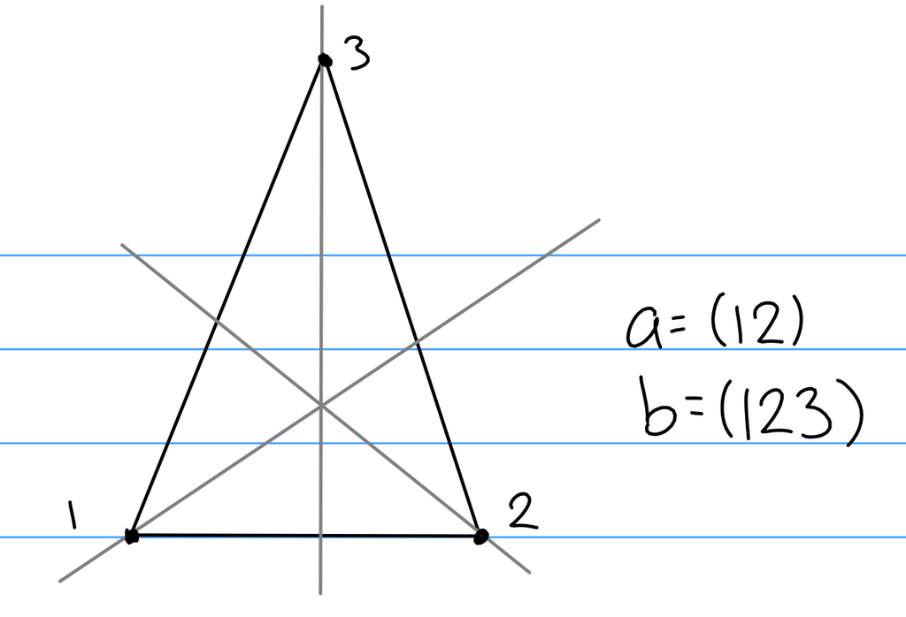

## Groups of Order 10

For order 10, a similar argument yields

$$\begin{align*} G = \left\langle{a, b \mathrel{\Big|}a^5 = 1, b^2 = 1, ba=a^4b}\right\rangle ,\end{align*}$$
and this is realized by symmetries of the pentagon where $a = (1~2~3~4~5), b=(1~4)(2~3)$.

## Groups of Order 8

Assume $G$ is nonabelian of order 8. $G$ has no elements of order 8, so the only possibilities for orders of elements are 1, 2, or 4.

Assume all elements have order 1 or 2. Let $a,b\in G$, consider
$$\begin{align*} (ab)^2 = abab \implies ab=b^{-1}a^{-1}= ba ,\end{align*}$$
and thus $G$ is abelian. So there must be an element of order 4.

So suppose $a\in G$ has order 4, which is an index 2 subgroup, and so $\left\langle{a}\right\rangle {~\trianglelefteq~}G$.

But ${\left\lvert {G/\left\langle{a}\right\rangle} \right\rvert} = 2$ is cyclic, so $G/\left\langle{a}\right\rangle = \left\langle{bH}\right\rangle$.

> Note that $b^2 \in H = \left\langle{a}\right\rangle$.

If $b^2=a, a^3$ then $b$ will have order 8, making $G$ cyclic. So $b^2 = 1, a^2$. These are both valid possibilities.

Since $H {~\trianglelefteq~}G$, we have $b\left\langle{a}\right\rangle b^{-1}= \left\langle{a}\right\rangle$, and since $a$ has order 4, so does $bab^{-1}$.

So $bab^{-1}= a, a^3$, but $a$ is not an option because this would make $G$ abelian.

So we have two options:

$$\begin{align*} G_1 &= \left\langle{a, b \mathrel{\Big|}a^4 = 1, b^2=1, bab^{-1}= a^3}\right\rangle \\ G_2 &= \left\langle{a, b \mathrel{\Big|}a^4 = 1, b^2 = a^2, bab^{-1}= a^3}\right\rangle .\end{align*}$$

*Exercise*: prove $G_1 \not\cong G_2$.

## Some Nice Facts

- If and $\phi: G\to G'$, then
  - $N {~\trianglelefteq~}G \implies N {~\trianglelefteq~}\phi(G)$, although it is not necessarily normal in $G$.
  - $N' {~\trianglelefteq~}G' \implies \phi^{-1}(N') {~\trianglelefteq~}G$

**Definition**: A *maximal normal subgroup* is a normal subgroup $M {~\trianglelefteq~}G$ that is properly contained in $G$, and if $M \leq N {~\trianglelefteq~}G$ (where $N$ is proper) then $M = N$.

**Theorem:** $M$ is a maximal normal subgroup of $G$ iff $G/M$ is simple.

## Simple Groups

**Definition**: A group $G$ is simple iff $N {~\trianglelefteq~}G \implies N = \left\{{e}\right\}, G$.

Note that if an abelian group has *any* subgroups, then it is not simple, so $G = {\mathbb{Z}}_p$ is the only simple abelian group. Another example of a simple group is $A_n$ for $n\geq 5$.

> Note that this is a consequence of the “odd order theorem”.

## Series of Groups

A composition series is a descending series of pairwise normal subgroups such that each successive quotient is simple:

$$\begin{align*} G_0 {~\trianglelefteq~}G_1 {~\trianglelefteq~}G_2 \cdots {~\trianglelefteq~}\left\{{e}\right\} \\ G_i/G_{i+1}~\text{ simple} .\end{align*}$$

*Example:*

$$\begin{align*} {\mathbb{Z}}_9 {~\trianglelefteq~}{\mathbb{Z}}_3 {~\trianglelefteq~}\left\{{e}\right\} \\ {\mathbb{Z}}_9 / {\mathbb{Z}}_3 = {\mathbb{Z}}_3,\\ {\mathbb{Z}}_3 / \left\{{e}\right\} = {\mathbb{Z}}_3 .\end{align*}$$

*Example:*

$$\begin{align*} {\mathbb{Z}}_6 {~\trianglelefteq~}{\mathbb{Z}}_3 {~\trianglelefteq~}\left\{{e}\right\} \\ {\mathbb{Z}}_6 / {\mathbb{Z}}_3 = {\mathbb{Z}}_2 \\ {\mathbb{Z}}_2 / \left\{{e}\right\} = {\mathbb{Z}}_2 .\end{align*}$$

but also

$$\begin{align*} {\mathbb{Z}}_6 {~\trianglelefteq~}{\mathbb{Z}}_2 {~\trianglelefteq~}\left\{{e}\right\} \\ {\mathbb{Z}}_6 / {\mathbb{Z}}_2 = {\mathbb{Z}}_3 \\ {\mathbb{Z}}_3 / \left\{{e}\right\} = {\mathbb{Z}}_3 .\end{align*}$$

**Theorem (Jordan-Holder):** Any two composition series are “isomorphic” in the sense that the same quotients appear in both series, up to a permutation.

**Definition:** A group is *solvable* iff it has a composition series where all factors are abelian.

*Exercise*: Show that any abelian group is solvable.

*Example:* $S_n$ is *not* solvable for $n\geq 5$, since

$$\begin{align*} S_n &{~\trianglelefteq~}A_n {~\trianglelefteq~}\left\{{e}\right\} \\ S_n / A_n &= {\mathbb{Z}}_2~\text{simple} \\ A_n / \left\{{e}\right\} &= A_n~\text{simple} \iff n\geq 5 .\end{align*}$$

*Example:*

$$\begin{align*} S_4 &{~\trianglelefteq~}A_4 {~\trianglelefteq~}G {~\trianglelefteq~}\left\{{e}\right\} \quad \text{where } {\left\lvert {H} \right\rvert} = 4 \\ S_4 / A_4 &= {\mathbb{Z}}_2 \\ A_4 / H &= {\mathbb{Z}}_3 \\ H / \left\{{e}\right\} &= \left\{{a, b}\right\}? .\end{align*}$$

# August 30th

Recall the Sylow theorems:

- $p$ groups exist for *every* $p^i$ dividing ${\left\lvert {G} \right\rvert}$, and $H(p) {~\trianglelefteq~}H(p^2) {~\trianglelefteq~}\cdots H(p^n)$.
- All Sylow $p{\hbox{-}}$subgroups are conjugate.
- Numerical constraints
  - $r_p \cong 1 \mod p$,
  - $r_p {~\Bigm|~}{\left\lvert {G} \right\rvert}$ and $r_p {~\Bigm|~}m$,

## Internal Direct Products

Suppose $H, K \leq G$, and consider the smallest subgroup containing both $H$ and $K$. Denote this $H \vee K$.

If either $H$ or $K$ is normal in $G$, then we have $H\vee K = HK$.

There is a “recipe” for proving you have a direct product of groups:

**Theorem (Recognizing Direct Products)**: Let $G$ be a group, $H {~\trianglelefteq~}G$ and $K{~\trianglelefteq~}G$, and

1. $H\vee K = HK = G$,
2. $H \cap K = \left\{{e}\right\}$.

Then $G \cong H \times K$.

*Proof:* We first want to show that $hk = kh ~\forall k\in K, h\in H$. We then have
$$\begin{align*} hkh^{-1}k^{-1}= (hkh^{-1})k^{-1}\in K = h(kh^{-1}k^{-1}) \in H \implies hkh^{-1}k^{-1}\in H\cap K = \left\{{e}\right\}. \end{align*}$$

So define

$$\begin{align*} \phi: H \times K \to G \\ (h, k) \mapsto hk ,\end{align*}$$

*Exercise:* check that this is a homomorphism, it is surjective, and injective.

$\hfill\blacksquare$

*Applications:*

**Theorem:** Every group of order $p^2$ is abelian.

*Proof:* If $G$ is cyclic, then it is abelian and $G \cong {\mathbb{Z}}_{p^2}$. So suppose otherwise. By Cauchy, there is an element of order $p$ in $G$. So let $H = \left\langle{a}\right\rangle$, for which we have ${\left\lvert {H} \right\rvert} = p$.

Then $H {~\trianglelefteq~}G$ by Sylow 1, since it’s normal in $H(p^2)$, which would have to equal $G$.

Now consider $b\not\in H$. By Lagrange, we must have $o(b) = 1, p$, and since $e\in H$, we must have $o(b) = p$. This uses fact that $G$ is not cyclic.

Now let $K = \left\langle{b}\right\rangle$. Then ${\left\lvert {K} \right\rvert} = p$, and $K {~\trianglelefteq~}G$ by the same argument.

$\hfill\blacksquare$

**Theorem:** Let ${\left\lvert {G} \right\rvert} = pq$ where $q\neq 1 \mod p$ and $p < q$. Then $G$ is cyclic (and thus abelian).

*Proof:* Use Sylow 1. Let $P$ be a sylow $p{\hbox{-}}$subgroup. We want to show that $P {~\trianglelefteq~}G$ to apply our direct product lemma, so it suffices to show $r_p = 1$.

We know $r_p = 1 \mod p$ and $r_p {~\Bigm|~}{\left\lvert {G} \right\rvert} = pq$, and so $r_p = 1,q$. It can’t be $q$ because $p < q$.

Now let $Q$ be a sylow $q{\hbox{-}}$subgroup. Then $r_q \cong 1 \mod 1$ and $r_q {~\Bigm|~}pq$, so $r_q = 1, q$. But since $p< q$, we must have $r_q = 1$. So $Q {~\trianglelefteq~}G$ as well.

We now have $P \cap Q = \emptyset$ (why?) and
$$\begin{align*} {\left\lvert {PQ} \right\rvert} = \frac{{\left\lvert {P} \right\rvert} {\left\lvert {Q} \right\rvert}}{ {\left\lvert {P \cap Q} \right\rvert} } = {\left\lvert {P} \right\rvert} {\left\lvert {Q} \right\rvert} = pq, \end{align*}$$

and so $G = PQ$, and $G \cong {\mathbb{Z}}_p \times{\mathbb{Z}}_q \cong {\mathbb{Z}}_{pq}$.

$\hfill\blacksquare$

*Example:* Every group of order $15 = 5^1 3^1$ is cyclic.

## Determination of groups of a given order

| Order of G | Number of Groups | List of Distinct Groups |
| --- | --- | --- |
| 1 | 1 | $\left\{{e}\right\}$ |
| 2 | 1 | ${\mathbb{Z}}_2$ |
| 3 | 1 | ${\mathbb{Z}}_3$ |
| 4 | 2 | ${\mathbb{Z}}_4, {\mathbb{Z}}_2^2$ |
| 5 | 1 | ${\mathbb{Z}}_5$ |
| 6 | 2 | ${\mathbb{Z}}_6, S_3$ (*) |
| 7 | 1 | ${\mathbb{Z}}_7$ |
| 8 | 5 | ${\mathbb{Z}}_8,{\mathbb{Z}}_4 \times{\mathbb{Z}}_2, {\mathbb{Z}}_2^3, D_8,Q$ |
| 9 | 2 | ${\mathbb{Z}}_9, {\mathbb{Z}}_3^2$ |
| 10 | 2 | ${\mathbb{Z}}_{10}, D_5$ |
| 11 | 1 | ${\mathbb{Z}}_{11}$ |

We still need to justify 6, 8, and 10.

## Free Groups

Define an *alphabet* $A = \left\{{a_1, a_2, \cdots a_n}\right\}$, and let a *syllable* be of the form $a_i^m$ for some $m$. A *word* is any expression of the form $\prod_{n_i} a_{n_i}^{m_i}$.

We have two operations,

- Concatenation, i.e. $(a_1 a_2) \star (a_3^2 a_5) = a_1 a_2 a_3^2 a_5$.
- Contraction, i.e. $(a_1 a_2^2) \star (a_2^{-1}a_5) = a_1 a_2^2 a_2^{-1}a_5 = a_1 a_2 a_5$.

If we’ve contracted a word as much as possible, we say it is *reduced*.

We let $F[A]$ be the set of reduced words and define a binary operation

$$\begin{align*} f: F[A] \times F[A] &\to F[A] \\ (w_1, w_2) &\mapsto w_1 w_2 \text{ (reduced) } .\end{align*}$$

**Theorem:** $(A, f)$ is a group.

*Proof:* Exercise.

$\hfill\blacksquare$

**Definition:** $F[A]$ is called the **free group generated by $A$**. A group $G$ is called *free* on a subset $A \subseteq G$ iff $G \cong F[A]$.

*Examples:*

1. $A = \left\{{x}\right\} \implies F[A] = \left\{{x^n {~\mathrel{\Big|}~}n \in {\mathbb{Z}}}\right\} \cong {\mathbb{Z}}$.
2. $A = \left\{{x, y}\right\} \implies F[A] = {\mathbb{Z}}\ast {\mathbb{Z}}$ (not defined yet!).

Note that there are not relations, i.e. $xyxyxy$ is *reduced*. To abelianize, we’d need to introduce the relation $xy = yx$.

*Properties:*

1. If $G$ is free on $A$ and free on $B$ then we must have ${\left\lvert {A} \right\rvert} = {\left\lvert {B} \right\rvert}$.
2. Any (nontrivial) subgroup of a free group is free.

   > (See Fraleigh or Hungerford for possible Algebraic proofs!)

**Theorem:** Let $G$ be generated by some (possibly infinite) subset $A = \left\{{A_i\mathrel{\Big|}i\in I}\right\}$ and $G'$ be generated by some $A_i' \subseteq A_i$.

Then

1. There is at most one homomorphism $a_i \to a_i'$.
2. If $G \cong F[A]$, there is exactly *one* homomorphism.

**Corollary:** Every group $G'$ is a homomorphic image of a free group.

*Proof:* Let $A$ be the generators of $G'$ and $G = F[A]$, then define

$$\begin{align*} \phi: F[A] &\to G' \\ a_i &\mapsto a_i .\end{align*}$$

This is onto exactly because $G' = \left\langle{a_i}\right\rangle$, and using the theorem above we’re done.

$\hfill\blacksquare$

## Generators and Relations

Let $G$ be a group and $A \subseteq G$ be a generating subset so $G = \left\langle{a \mathrel{\Big|}a\in A}\right\rangle$. There exists a $\phi: F[A] \twoheadrightarrow G$, and by the first isomorphism theorem, we have $F[A] / \ker \phi \cong G$.

Let $R = \ker \phi$, these provide the *relations*.

*Examples:*

Let $G = {\mathbb{Z}}_3 = \left\langle{[1]_3}\right\rangle$. Let $x = [1]_3$, then define $\phi: F[\left\{{x}\right\}] \twoheadrightarrow{\mathbb{Z}}_3$.

Then since $[1] + [1] + [1] = [0] \mod 3$, we have $\ker \phi = \left\langle{x^3}\right\rangle$.

Let $G = {\mathbb{Z}}\oplus {\mathbb{Z}}$, then $G \cong \left\langle{x,y \mathrel{\Big|}[x,y] = 1}\right\rangle$.

> We’ll use this for groups of order 6 – there will be only one presentation that is nonabelian, and we’ll exhibit such a group.